# CH10 Lab

# Lab 1 PCA

Working with `USArrests` data from base R.

```r
data(USArrests)
states <- row.names(USArrests)
print(states)
```

```
##  [1] "Alabama"        "Alaska"         "Arizona"        "Arkansas"
##  [5] "California"     "Colorado"       "Connecticut"    "Delaware"
##  [9] "Florida"        "Georgia"        "Hawaii"         "Idaho"
## [13] "Illinois"       "Indiana"        "Iowa"           "Kansas"
## [17] "Kentucky"       "Louisiana"      "Maine"          "Maryland"
## [21] "Massachusetts"  "Michigan"       "Minnesota"      "Mississippi"
## [25] "Missouri"       "Montana"        "Nebraska"       "Nevada"
## [29] "New Hampshire"  "New Jersey"     "New Mexico"     "New York"
## [33] "North Carolina" "North Dakota"   "Ohio"           "Oklahoma"
## [37] "Oregon"         "Pennsylvania"   "Rhode Island"   "South Carolina"
## [41] "South Dakota"   "Tennessee"      "Texas"          "Utah"
## [45] "Vermont"        "Virginia"       "Washington"     "West Virginia"
## [49] "Wisconsin"      "Wyoming"
```

```r
## summary stats with apply on columns
print ( apply(USArrests, MARGIN=2,mean) )
```

```
##   Murder  Assault UrbanPop     Rape
##    7.788  170.760   65.540   21.232
```

```r
print ( apply(USArrests, MARGIN=2,sd) )
```

```
##    Murder   Assault  UrbanPop      Rape
##  4.355510 83.337661 14.474763  9.366385
```

Perform PCA

```r
pr.out <- prcomp(USArrests, scale=TRUE) #scaling normalize variables.

print( names(pr.out) )
```

```
## [1] "sdev"     "rotation" "center"   "scale"    "x"
```

```r
print ( pr.out$center)
```

```
##   Murder  Assault UrbanPop     Rape
##    7.788  170.760   65.540   21.232
```

```r
print ( pr.out$scale)
```

```
##    Murder   Assault  UrbanPop      Rape
##  4.355510 83.337661 14.474763  9.366385
```

```r
print ( pr.out ) # PCA details  Rotains shows the loadings of feature to components
```

```
## Standard deviations (1, .., p=4):
## [1] 1.5748783 0.9948694 0.5971291 0.4164494
##
## Rotation (n x k) = (4 x 4):
##                 PC1        PC2        PC3         PC4
## Murder   -0.5358995  0.4181809 -0.3412327  0.64922780
## Assault  -0.5831836  0.1879856 -0.2681484 -0.74340748
## UrbanPop -0.2781909 -0.8728062 -0.3780158  0.13387773
## Rape     -0.5434321 -0.1673186  0.8177779  0.08902432
```

biplot is a very useful visualization

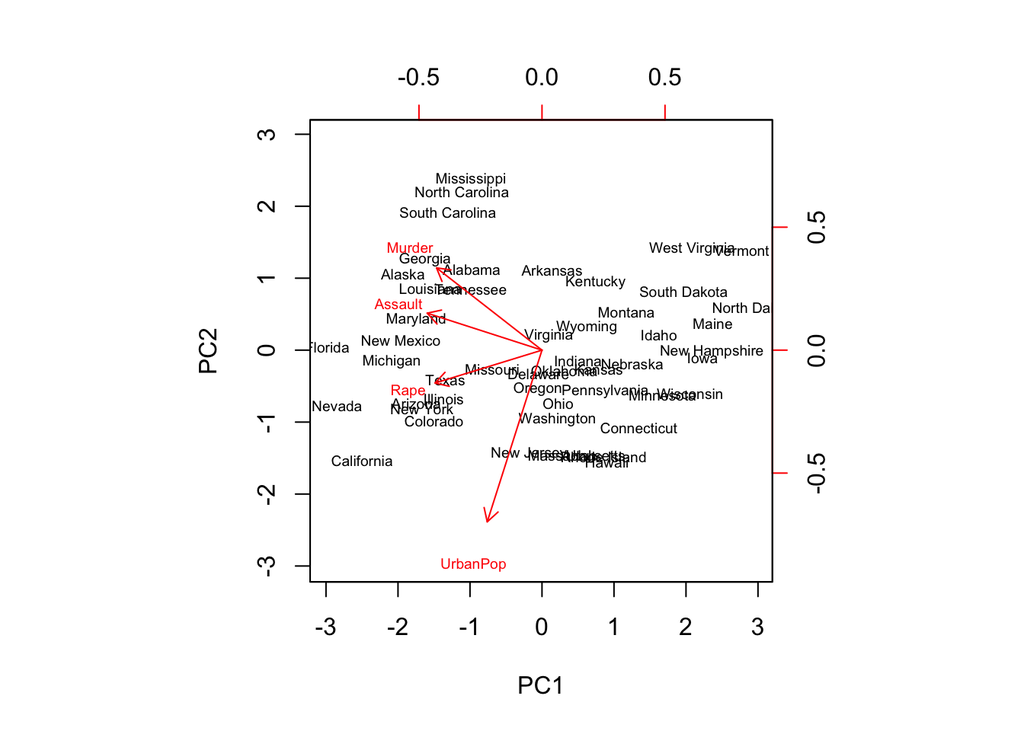

```r
biplot(pr.out,scale=0, cex=0.6) ##useful visualization
```

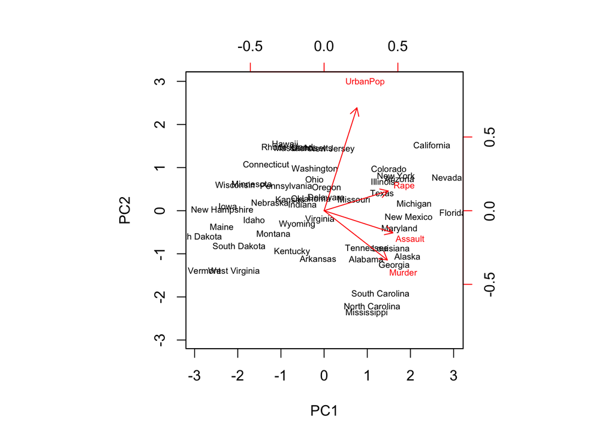

```r
#to make a 180 flip of the plot
pr.out$rotation <- -pr.out$rotation
pr.out$x <- - pr.out$x
biplot(pr.out,scale=0, cex=0.6)
```

#####Compute a proportion of variance explained

```r
print(pr.out$sdev )  #SDevs
```

```
## [1] 1.5748783 0.9948694 0.5971291 0.4164494
```

```r
pr.var <- pr.out$sdev^2

pve <- pr.var / sum(pr.var)
print(paste("proportion of variance explained:",paste(pve,collapse=" ") ))
```

```
## [1] "proportion of variance explained: 0.620060394787373 0.24744128813496 0.0891407951452075 0.0433575219324588"
```

#####Chart PVE

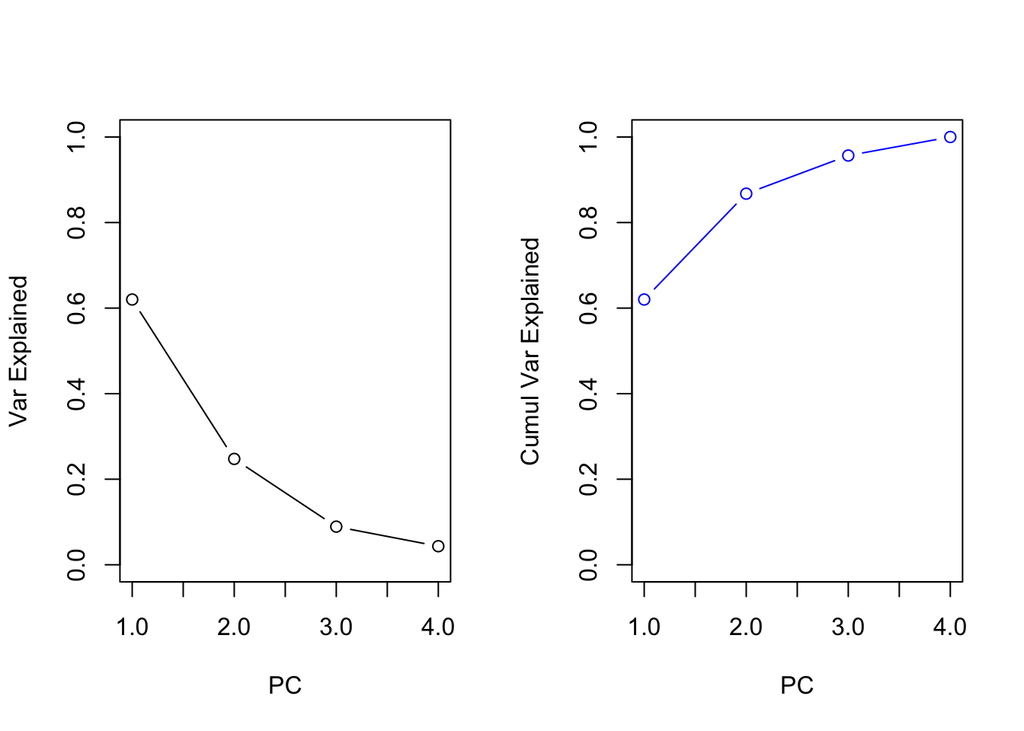

```r
par(mfrow=c(1,2))
plot(pve, xlab="PC", ylab="Var Explained", ylim=c(0,1), type="b" )
plot(cumsum(pve), xlab="PC", ylab="Cumul Var Explained", col="blue", ylim=c(0,1), type="b" )
```

```r
par(mfrow=c(1,1))
```

# Lab 2 Clustering

#####generate data

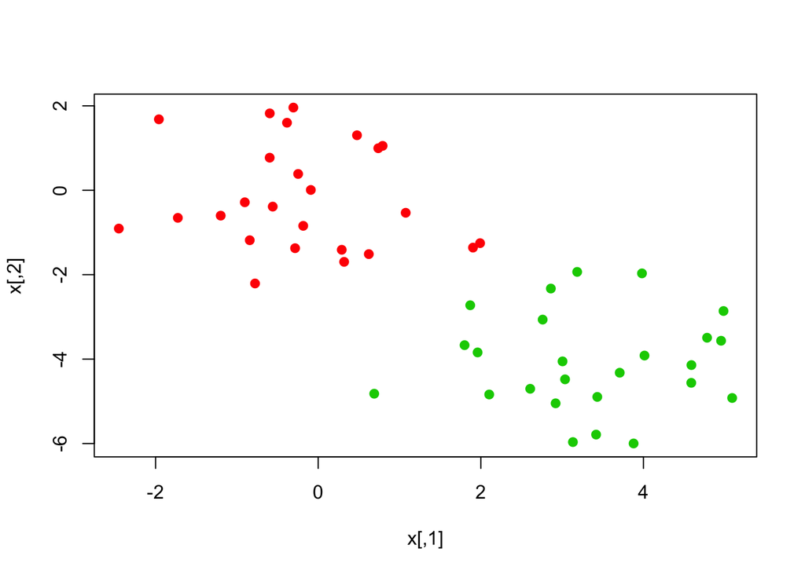

```r
set.seed(2)
n <- 50
nh <- n/2
x <- matrix(rnorm(n*2),ncol=2)
x[1:nh,1] =x[1:nh,1] + 3
x[1:nh,2] =x[1:nh,2] - 4

y <- c( rep(3,nh), rep(2,nh))
plot(x,col=y, pch=19)
```

##### perform k-means clustering withK = 2

```r
km.out <- kmeans(x, centers=2,nstart=20)

print(km.out )
```

```
## K-means clustering with 2 clusters of sizes 25, 25
##
## Cluster means:
##         [,1]       [,2]
## 1 -0.1956978 -0.1848774
## 2  3.3339737 -4.0761910
##
## Clustering vector:
##  [1] 2 2 2 2 2 2 2 2 2 2 2 2 2 2 2 2 2 2 2 2 2 2 2 2 2 1 1 1 1 1 1 1 1 1 1
## [36] 1 1 1 1 1 1 1 1 1 1 1 1 1 1 1
##
## Within cluster sum of squares by cluster:
## [1] 65.40068 63.20595
##  (between_SS / total_SS =  72.8 %)
##
## Available components:
##
## [1] "cluster"      "centers"      "totss"        "withinss"
## [5] "tot.withinss" "betweenss"    "size"         "iter"
## [9] "ifault"
```

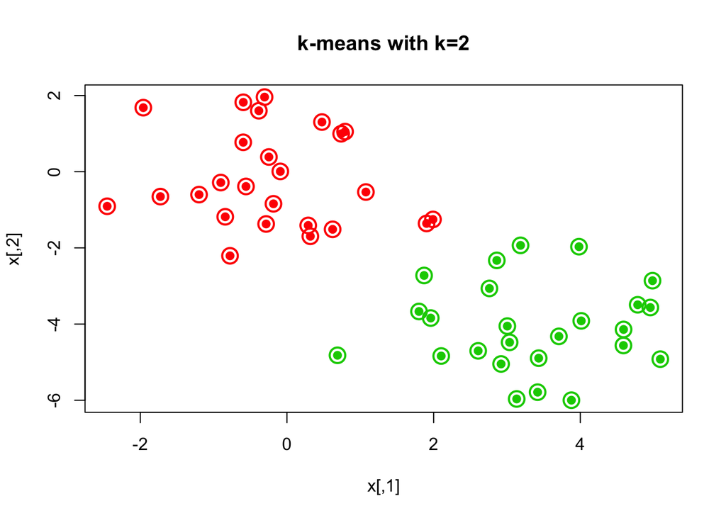

```r
plot(x,col=(km.out$cluster+1) , main="k-means with k=2", pch=1, cex=2, lwd=2 )
#check the clastered classification with true label
points(x,col=y, pch=19)
```

We see that there is zero mistmatch between k-means and true labels

In real world K is unknown lets try kmeans with k=3

```r
set.seed(4)
km.out <- kmeans(x,centers=3,nstart=20) #recommended value for nstart 20 or 50
print(km.out)
```

```
## K-means clustering with 3 clusters of sizes 10, 23, 17
##
## Cluster means:
##         [,1]        [,2]
## 1  2.3001545 -2.69622023
## 2 -0.3820397 -0.08740753
## 3  3.7789567 -4.56200798
##
## Clustering vector:
##  [1] 3 1 3 1 3 3 3 1 3 1 3 1 3 1 3 1 3 3 3 3 3 1 3 3 3 2 2 2 2 2 2 2 2 2 2
## [36] 2 2 2 2 2 2 2 2 1 2 1 2 2 2 2
##
## Within cluster sum of squares by cluster:
## [1] 19.56137 52.67700 25.74089
##  (between_SS / total_SS =  79.3 %)
##
## Available components:
##
## [1] "cluster"      "centers"      "totss"        "withinss"
## [5] "tot.withinss" "betweenss"    "size"         "iter"
## [9] "ifault"
```

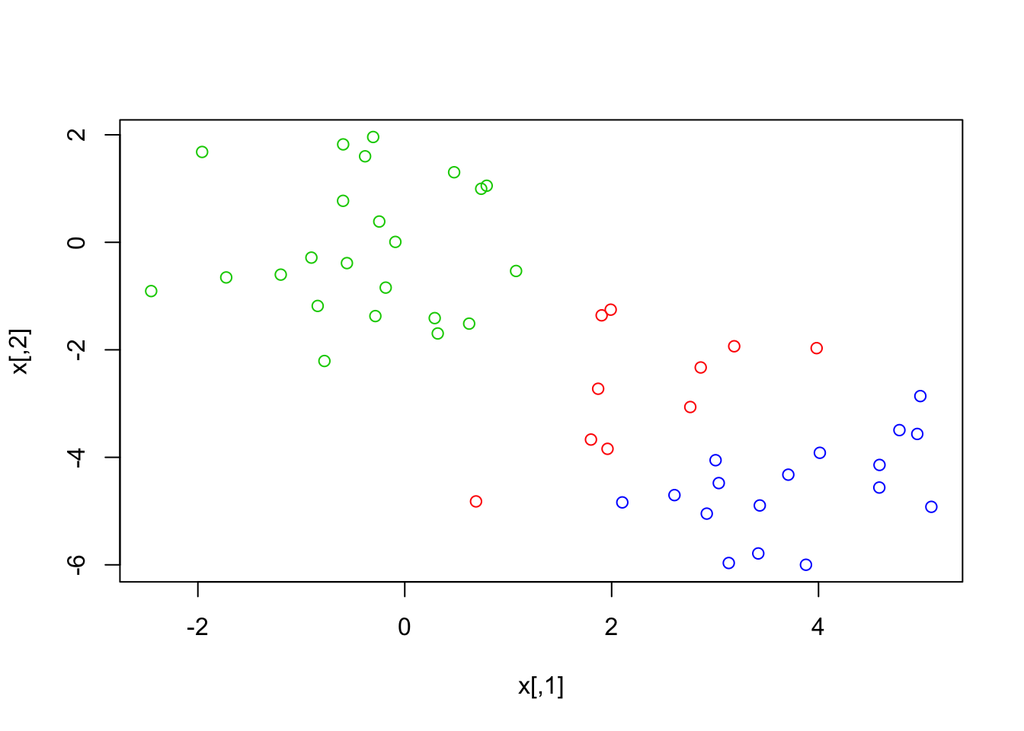

```r
plot(x,col=(km.out$cluster+1) )
```

We observe 3 classes found by k-means

# Hierarchical clustering

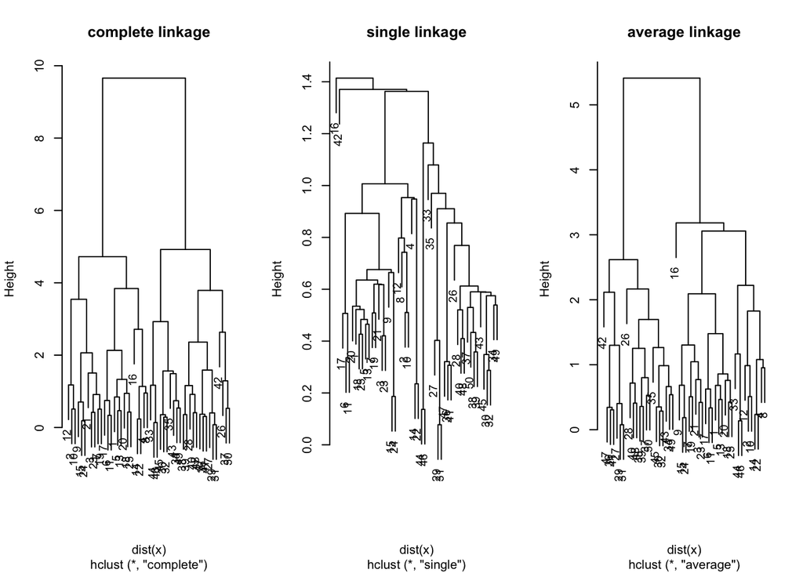

```r
hc.complete <- hclust(dist(x), method="complete")
hc.single <- hclust(dist(x), method="single")
hc.avg <- hclust(dist(x), method="average")
par(mfrow=c(1,3))
plot(hc.complete, main="complete linkage", cex=.9)
plot(hc.single, main="single linkage", cex=.9)
plot(hc.avg, main="average linkage", cex=.9)
```

To determine the cluster labels for each observation associated with a given cut of the dendrogram

```r
print( cutree(hc.complete, 2))
```

```
##  [1] 1 1 1 1 1 1 1 1 1 1 1 1 1 1 1 1 1 1 1 1 1 1 1 1 1 2 2 2 2 2 2 2 2 2 2
## [36] 2 2 2 2 2 2 2 2 2 2 2 2 2 2 2
```

```r
print( cutree(hc.single, 2))
```

```
##  [1] 1 1 1 1 1 1 1 1 1 1 1 1 1 1 1 2 1 1 1 1 1 1 1 1 1 1 1 1 1 1 1 1 1 1 1
## [36] 1 1 1 1 1 1 1 1 1 1 1 1 1 1 1
```

```r
print( cutree(hc.avg, 2))
```

```
##  [1] 1 1 1 1 1 1 1 1 1 1 1 1 1 1 1 1 1 1 1 1 1 1 1 1 1 2 2 2 2 2 2 2 1 2 2
## [36] 2 2 2 2 2 2 2 2 1 2 1 2 2 2 2
```

Lets check the hi-clustering with variables scaled before clustering

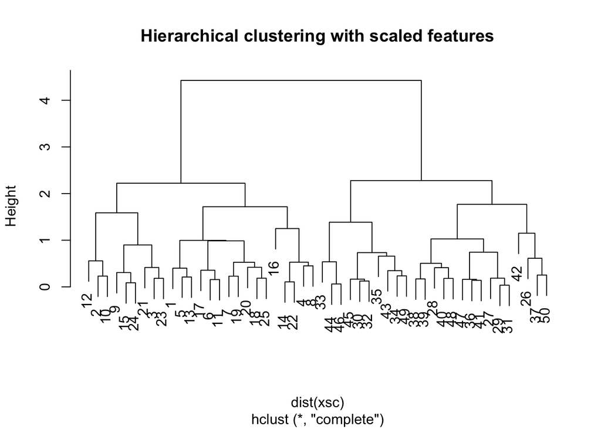

```r
xsc <- scale(x)
plot(hclust(dist(xsc), method="complete"), main="Hierarchical clustering with scaled features" )
```

Clustering of correlation based distance. Need to have at least 3 features

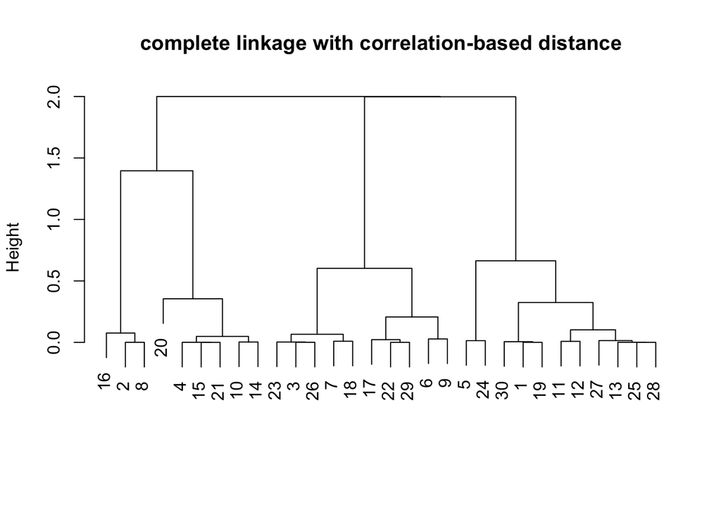

```r
x<-matrix(rnorm(30*3),ncol=3)
dd<-as.dist(1-cor(t(x)))  # as.dist
plot(hclust(dd, method="complete"), main="complete linkage with correlation-based distance", xlab="",sub="")
```

# Lab 3 NC160 Data example

```r
require(ISLR)
data(NCI60) #genomic data
nci.labs <- NCI60$labs
nci.data <- NCI60$data
print( dim(nci.data))
```

```
## [1]   64 6830
```

```r
print( table(nci.labs) )
```

```
## nci.labs
##      BREAST         CNS       COLON K562A-repro K562B-repro    LEUKEMIA
##           7           5           7           1           1           6
## MCF7A-repro MCF7D-repro    MELANOMA       NSCLC     OVARIAN    PROSTATE
##           1           1           8           9           6           2
##       RENAL     UNKNOWN
##           9           1
```

####Perform PCA

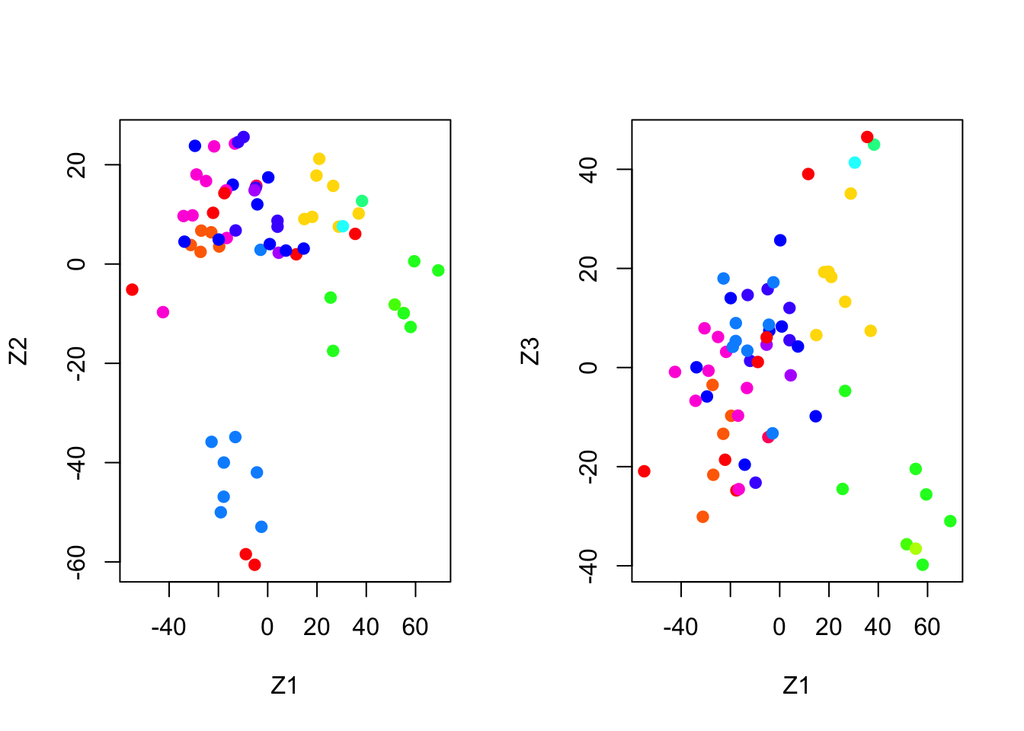

```r
pr.out <- prcomp(nci.data, scale=TRUE)

#func to assing colors to each of 64 lines
Cols <-function(vec){
    cols <- rainbow(length(unique(vec)))
    return(cols[as.numeric(as.factor(vec))])
}


par(mfrow=c(1,2))
plot(pr.out$x[,1:2],col=Cols(nci.labs),pch=19, xlab="Z1", ylab="Z2")
plot(pr.out$x[,c(1,3)],col=Cols(nci.labs),pch=19, xlab="Z1", ylab="Z3")
```

```r
par(mfrow=c(1,1))

print( summary(pr.out) )
```

```
## Importance of components:
##                            PC1      PC2      PC3      PC4      PC5
## Standard deviation     27.8535 21.48136 19.82046 17.03256 15.97181
## Proportion of Variance  0.1136  0.06756  0.05752  0.04248  0.03735
## Cumulative Proportion   0.1136  0.18115  0.23867  0.28115  0.31850
##                             PC6      PC7      PC8      PC9     PC10
## Standard deviation     15.72108 14.47145 13.54427 13.14400 12.73860
## Proportion of Variance  0.03619  0.03066  0.02686  0.02529  0.02376
## Cumulative Proportion   0.35468  0.38534  0.41220  0.43750  0.46126
##                            PC11     PC12     PC13     PC14     PC15
## Standard deviation     12.68672 12.15769 11.83019 11.62554 11.43779
## Proportion of Variance  0.02357  0.02164  0.02049  0.01979  0.01915
## Cumulative Proportion   0.48482  0.50646  0.52695  0.54674  0.56590
##                            PC16     PC17     PC18     PC19    PC20
## Standard deviation     11.00051 10.65666 10.48880 10.43518 10.3219
## Proportion of Variance  0.01772  0.01663  0.01611  0.01594  0.0156
## Cumulative Proportion   0.58361  0.60024  0.61635  0.63229  0.6479
##                            PC21    PC22    PC23    PC24    PC25    PC26
## Standard deviation     10.14608 10.0544 9.90265 9.64766 9.50764 9.33253
## Proportion of Variance  0.01507  0.0148 0.01436 0.01363 0.01324 0.01275
## Cumulative Proportion   0.66296  0.6778 0.69212 0.70575 0.71899 0.73174
##                           PC27   PC28    PC29    PC30    PC31    PC32
## Standard deviation     9.27320 9.0900 8.98117 8.75003 8.59962 8.44738
## Proportion of Variance 0.01259 0.0121 0.01181 0.01121 0.01083 0.01045
## Cumulative Proportion  0.74433 0.7564 0.76824 0.77945 0.79027 0.80072
##                           PC33    PC34    PC35    PC36    PC37    PC38
## Standard deviation     8.37305 8.21579 8.15731 7.97465 7.90446 7.82127
## Proportion of Variance 0.01026 0.00988 0.00974 0.00931 0.00915 0.00896
## Cumulative Proportion  0.81099 0.82087 0.83061 0.83992 0.84907 0.85803
##                           PC39    PC40    PC41   PC42    PC43   PC44
## Standard deviation     7.72156 7.58603 7.45619 7.3444 7.10449 7.0131
## Proportion of Variance 0.00873 0.00843 0.00814 0.0079 0.00739 0.0072
## Cumulative Proportion  0.86676 0.87518 0.88332 0.8912 0.89861 0.9058
##                           PC45   PC46    PC47    PC48    PC49    PC50
## Standard deviation     6.95839 6.8663 6.80744 6.64763 6.61607 6.40793
## Proportion of Variance 0.00709 0.0069 0.00678 0.00647 0.00641 0.00601
## Cumulative Proportion  0.91290 0.9198 0.92659 0.93306 0.93947 0.94548
##                           PC51    PC52    PC53    PC54    PC55    PC56
## Standard deviation     6.21984 6.20326 6.06706 5.91805 5.91233 5.73539
## Proportion of Variance 0.00566 0.00563 0.00539 0.00513 0.00512 0.00482
## Cumulative Proportion  0.95114 0.95678 0.96216 0.96729 0.97241 0.97723
##                           PC57   PC58    PC59    PC60    PC61    PC62
## Standard deviation     5.47261 5.2921 5.02117 4.68398 4.17567 4.08212
## Proportion of Variance 0.00438 0.0041 0.00369 0.00321 0.00255 0.00244
## Cumulative Proportion  0.98161 0.9857 0.98940 0.99262 0.99517 0.99761
##                           PC63      PC64
## Standard deviation     4.04124 1.956e-14
## Proportion of Variance 0.00239 0.000e+00
## Cumulative Proportion  1.00000 1.000e+00
```

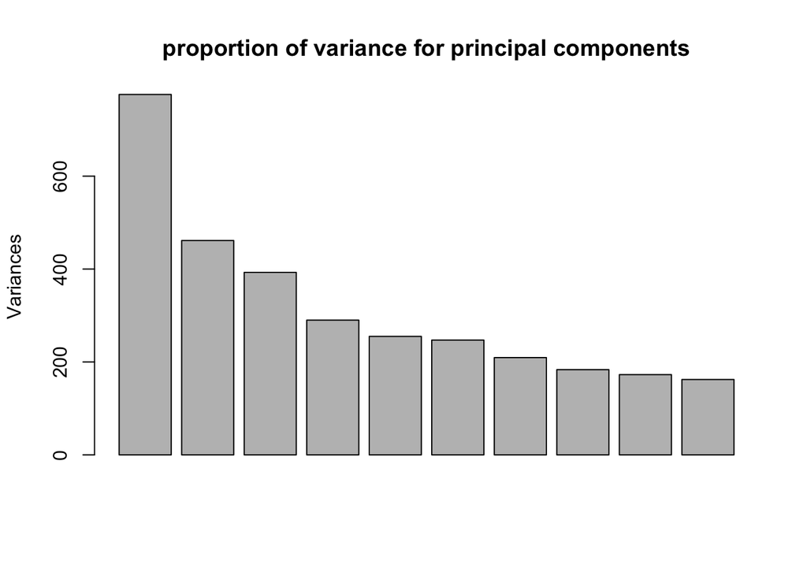

```r
plot(pr.out, main="proportion of variance for principal components")
```

A better proportion of variance (PVE) chart

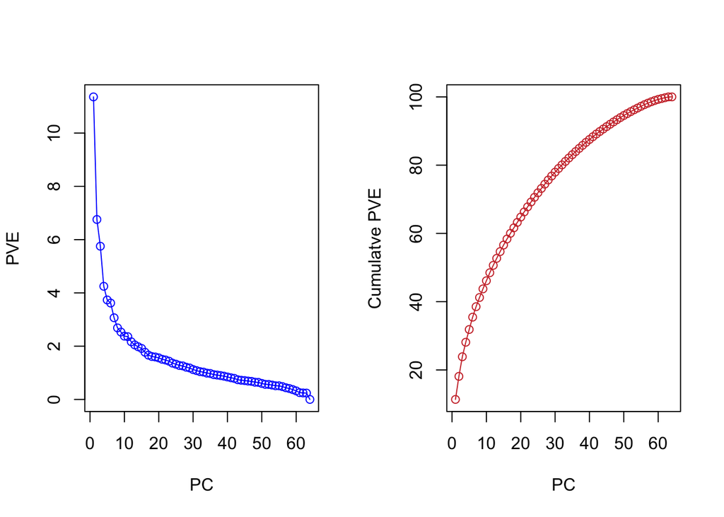

```r
pve <- 100*pr.out$sdev^2/sum(pr.out$sdev^2)
par(mfrow=c(1,2))
plot(pve, type="o", ylab="PVE", xlab="PC", col="blue")
plot(cumsum(pve), type="o", ylab="Cumulatve PVE", xlab="PC", col="brown3")
```

```r
par(mfrow=c(1,1))
```

This suggest there may be little benefit to examining more than seven or so principal components.

# Clustering the observations of NCI60 Data

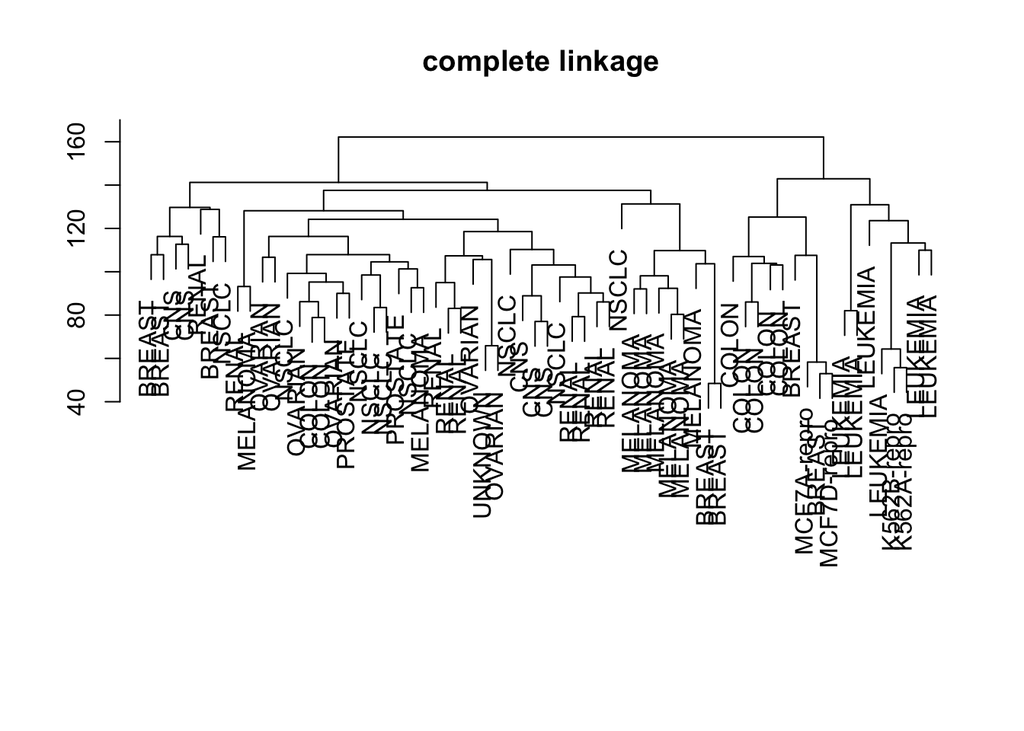

```r
sd.data <- scale(nci.data)
data.dist <- dist(sd.data)

plot(hclust(data.dist), labels=nci.labs, main="complete linkage", xlab="", sub="",ylab="")
```

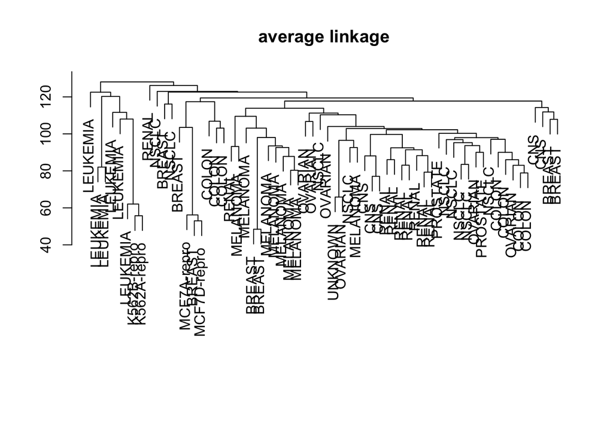

```r
plot(hclust(data.dist, method="average"), labels=nci.labs, main="average linkage", xlab="", sub="",ylab="")
```

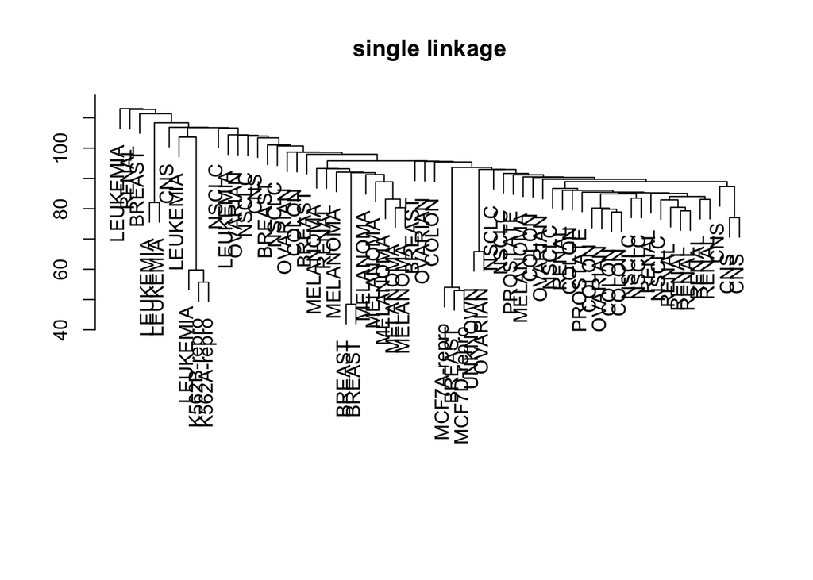

```r
plot(hclust(data.dist, method="single"), labels=nci.labs, main="single linkage", xlab="", sub="",ylab="")
```

We will use complete linkage hierarchical clustering for the further analysis

```r
hc.out <- hclust(dist(sd.data))
hc.clusters <- cutree(hc.out,4) #cut for 4 clusters
cm <- table(hc.clusters, nci.labs)
print(cm)
```

```
##            nci.labs
## hc.clusters BREAST CNS COLON K562A-repro K562B-repro LEUKEMIA MCF7A-repro
##           1      2   3     2           0           0        0           0
##           2      3   2     0           0           0        0           0
##           3      0   0     0           1           1        6           0
##           4      2   0     5           0           0        0           1
##            nci.labs
## hc.clusters MCF7D-repro MELANOMA NSCLC OVARIAN PROSTATE RENAL UNKNOWN
##           1           0        8     8       6        2     8       1
##           2           0        0     1       0        0     1       0
##           3           0        0     0       0        0     0       0
##           4           1        0     0       0        0     0       0
```

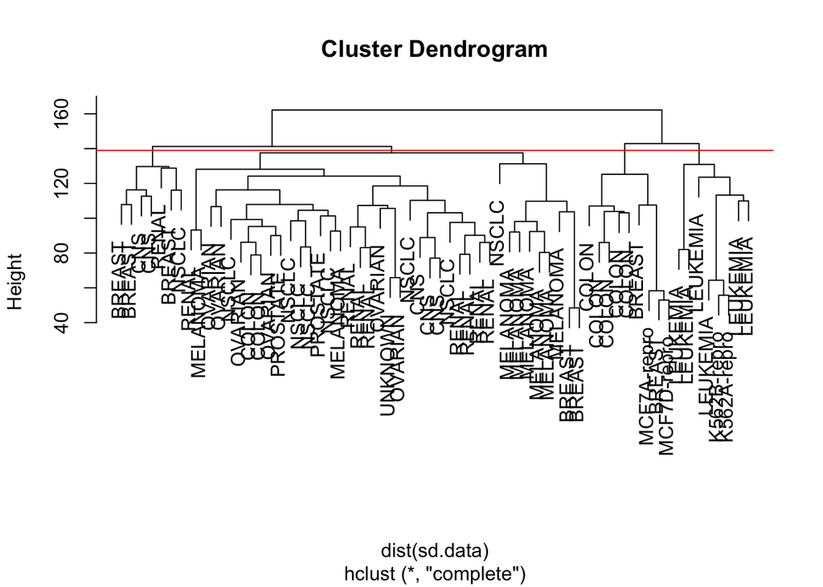

```r
plot(hc.out, labels=nci.labs)
abline(h=139, col="red")
```

```r
print(hc.out)
```

```
##
## Call:
## hclust(d = dist(sd.data))
##
## Cluster method   : complete
## Distance         : euclidean
## Number of objects: 64
```

Lets compare it with k-means clustering with 4 clusters

```r
set.seed(2)
km.out <- kmeans(sd.data, 4, nstart=20)
km.clusters=km.out$cluster
cm <- table(kmeans=km.clusters, hierarch=hc.clusters)
print(cm)
```

```
##       hierarch
## kmeans  1  2  3  4
##      1 11  0  0  9
##      2  0  0  8  0
##      3  9  0  0  0
##      4 20  7  0  0
```

Lets perform hierarchical clustering on several principal components

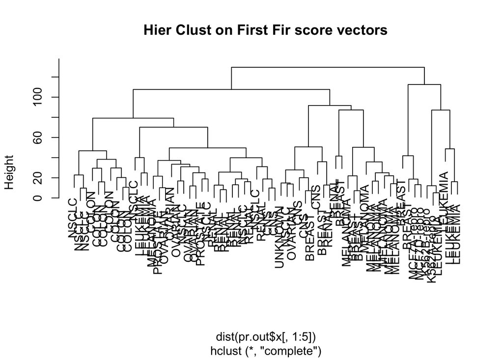

```r
hc.out <- hclust(dist(pr.out$x[,1:5]))
plot(hc.out, labels=nci.labs, main="Hier Clust on First Fir score vectors" )
```

```r
cm <- table(hcpc=cutree(hc.out,4),truth=nci.labs)
print(cm)
```

```
##     truth
## hcpc BREAST CNS COLON K562A-repro K562B-repro LEUKEMIA MCF7A-repro
##    1      0   2     7           0           0        2           0
##    2      5   3     0           0           0        0           0
##    3      0   0     0           1           1        4           0
##    4      2   0     0           0           0        0           1
##     truth
## hcpc MCF7D-repro MELANOMA NSCLC OVARIAN PROSTATE RENAL UNKNOWN
##    1           0        1     8       5        2     7       0
##    2           0        7     1       1        0     2       1
##    3           0        0     0       0        0     0       0
##    4           1        0     0       0        0     0       0
```

These results are different from the ones that we obtained when we performed hierarchical clustering on the full data set.